# SOES3056 Workflow Assignment

Periodicity and Long Time trends in Sea Ice at Bering Strait

Dawid Nehrenberg

25/12/2024

This assignment has used generative AI in the form of chatGPT-4o and Github Copilot using chatGPT-4o and Calude 3.5 Sonnet (preview) to aid creation and debugging of code.

#### Required Libraries

```r
 library(ncdf4) #reads netcdf data
 library(reshape) #dataframe manipulation
 library(cowplot) #composite figures
 library(tidyverse) #dplyr, ggplot, etc.
 library(WaveletComp) #Wavelet analysis
```

## 1. Introduction

The Bering Sea is a Polar Sea that acts as an oceanic gateway between the North Pacific and the Arctic Ocean. Here this region is defined with the bounds 50-70°N and 170-210°E (Figure 1). Periodicity and long-term trends are assessed using a subset of G10010 Version 2 gridded monthly sea ice and concentration dataset (Walsh et al., 2019) between 1850-2017. The original dataset has been subset to only include the region of interest due to the high resolution of the original dataset. The way in which the data set is subset is stored in a separate R script called “Data_selection.r” as it takes ~3 hours to run. This script simply extracts data from the original netcdf file with 1/4°x1/4° resolution and only selects the cells in the Bering Sea region and saves them to a new netcdf file called “Bering_Strait_Seaice_Concentration.nc”. This file is then used here for all map visualisations and for creation of total sea ice cover timeseries (Figure 2).

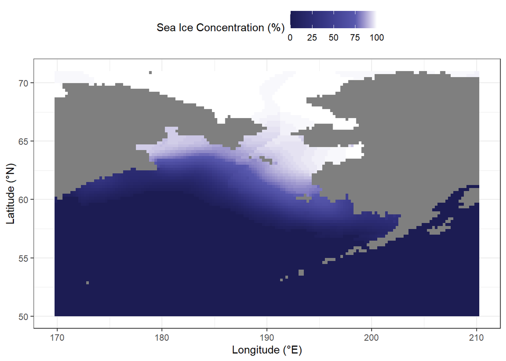

Figure 1, Map of Bering Strait

Sea ice an integral part of polar seas forming when sea water cools to -1.8°C. The megafauna of the Arctic heavily relies on sea ice as habitat, with key charismatic species like the ringed seals (*Pusa hispida*) and polar bears (*Ursus maritimus*) being ice obligate requiring sea ice for many of their essential behaviours such as pupping, hunting, and resting (Laidre et al., 2015). However, sea ice also plays an integral role for the base of the food chain as well as many arctic marine phytoplankton are adapted to grow underneath sea ice (Aicken, 1992).

Thus, the role and importance of sea ice is easy to understand as it plays a major role in the Arctic ecosystem. However, due to anthropogenic climate change this key form of habitat is at risk as sea temperatures continue to rise (Kim et al., 2020). Here we aim to identify key periodicities in the total sea ice cover record for the Bering Sea region, as well as identify any long-term temporal trends.

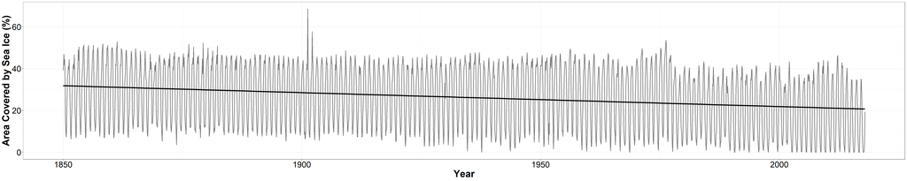

Figure 2, Time series of Sea Ice cover over time

## 2. Results

Here we find the main periodicity of sea ice in the Bering Sea region to be the 12-month seasonal cycle (Figure 3). This intra-annual variability is presented in Figure 4 where all 12 months of 1850 are visualised. Based on this we can surmise that the ice extent and concentration maxima occur during the boreal winter, with the minima occurring during the Summer. A secondary periodicity is also found at ~20 years (256 months) at a lower significance and power indicated by the region bounded in white (Figure 3).

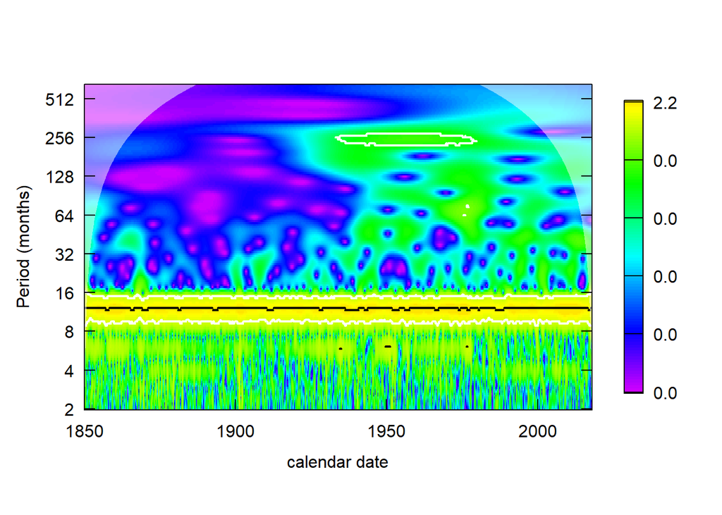

Fig 3, Wavelet analysis of sea ice cover time series

```r
#Linear regression for total sea ice cover over time
summary(lm(cover$cover ~ cover$date))
```

```
##
## Call:
## lm(formula = cover$cover ~ cover$date)
##
## Residuals:
##     Min      1Q  Median      3Q     Max
## -26.592 -14.786   2.657  13.526  40.016
##
## Coefficients:
##               Estimate Std. Error t value Pr(>|t|)
## (Intercept) 23.8394830  0.4038522  59.030   <2e-16 ***
## cover$date  -0.0001821  0.0000183  -9.952   <2e-16 ***
## ---
## Signif. codes:  0 '***' 0.001 '**' 0.01 '*' 0.05 '.' 0.1 ' ' 1
##
## Residual standard error: 14.55 on 2014 degrees of freedom
## Multiple R-squared:  0.04687,    Adjusted R-squared:  0.0464
## F-statistic: 99.04 on 1 and 2014 DF,  p-value: < 2.2e-16
```

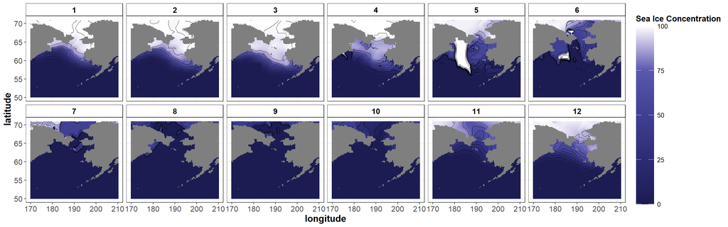

Figure 4, Timeseries of Sea Ice concentration and distribution within a year (1850)

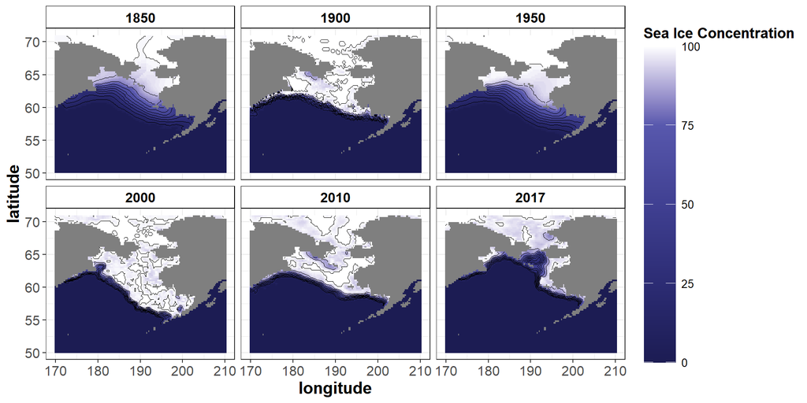

Figure 5, Timeseries of Janurary sea ice concentration and distribution at the Bering Strait

## 3. Discussion

Here we find the main mode of variability in the Bering Sea region to be the 12-month seasonal cycle, with possible influence from a 20 year oscillation (Figure 3). We also identify a significant (p < 0.01) decrease in total sea ice cover over the period studied, with this being also associated with a retreating winter ice extent (Figure 5).

The observed 12 month periodicity is likely to be related to the seasonal cycle in the northern hemisphere, with increasing solar radiation in the summer months being responsible for decreasing total sea ice cover (%). The range of values is then further modified by exogenous factors and low frequency oscillations, such as the Pacific Decadal Oscillation and Arctic Oscillation (AO), and sunspot cycles. The PDO is a low frequency oscillation with a period between 20-30 years that modulates North Pacific SST, which can influence sea ice formation (Kim et al., 2020). Thus, PDO could be considered a suitable explanation for the 20-year periodicity observed in our data.

However, another potential explanation for the periodicity found in the wavelet analysis (Figure 3) could be the AO. This is another climatic oscillation that has a 20-30 year period, and has been noted to affect North Pacific sea ice (Wang and Ikeda, 2000). Thus, it is difficult to distinguish the main cause of the observed periodicity in the data set as both oscillations have similar periodicities and would require further correlation analyses which are beyond the scope of this report.

Furthermore, total incoming solar radiation is highly variable on annual and inter-annual scales. Annual variability in incoming radiation is the primary driver of the seasonal cycle affecting factors such as sea and air temperatures. Solar radiation is also variable on inter-annual time frames with the 11 year sunspot cycle affecting the total incoming solar radiation that the planet receives (Schmutz, 2021). However, we do not record this cycle in the total sea ice cover record. This could indicate that the data contains too much noise from the inter annual variability to be identified. This hypothesis could be tested by calculating yearly means of total sea ice cover to remove the influence of the seasonal cycle from the analysis.

Whilst the total sea ice cover time series reveals the main oscillatory period of sea ice in the Bering Sea region it also reveals a decreasing trend in sea ice during the period. This is likely to be related to the increasing atmospheric CO2 concentration since the industrial revolution began and the global warming associated with it (Graven et al., 2020). Furthermore, the time series reveals a step wise reduction in total sea ice cover in the region around 1979. This is mostly likely to be due to changing method of observation; post 1979 the G10010 V2 dataset (Walsh et al., 2019) switches to being based on satellite data instead of historic observational data. After 2003 ice free summers become a common occurrence in the Bering Sea region, indicating that the system has reached a tipping point at which it is no longer able to sustain ice during the summer.

In summation the main control on total sea ice cover is the 12-month seasonal cycle with minima and maxima being forced by exogenous factors. A secondary significant mode of oscillation is proposed in the form of either the PDO or AO which affects sea ice cover on a time scale of ~ 20 years. Sea ice cover is also found to be decreasing over the time period studied with this likely being related to climate change. Furthermore, ice free summers in the region have become common place since 2003. These changes in the system are likely to have detrimental effects on fauna that are unable to adapt as sea ice becomes no longer present in their native ranges. Changes to sea ice extent and concentration, as well factors that influence them, will be important to consider when designing and designating marine protected areas so that they can be effective in preserving Arctic megafauna.

## 4. Methods

### 4.1 Total Sea Ice Cover

The code chunk below details how the data for the “Bering_Strait_Sea_Ice_Cover.csv” dataset is collated. The code has been commented out for computing efficiency as it takes 10+ minutes to run.

```r
#data_list <- list()
#for(i in seq_along(1:2016)){
#    temp_dat <- grab_File(path = "Data\\Bering_Strait_Seaice_Concentration.nc",
#                       d2variable = "seaice_conc", timeslice = i)
#    temp_dat <- map_Ready(df = temp_dat, lat = lat, lon = lon)
#    temp_dat$value[temp_dat$value > 0 & temp_dat$value <= 100] <- 1
#    temp_dat$value[temp_dat$value > 100] <- NA
#    ocn_cells <- length(na.omit(temp_dat$value))
#    ice_cover <- sum(temp_dat$value, na.rm = TRUE)
#    timestep <- as.character(i)
#    print(timestep) #not required just tells you if the command is still running
#    data_list[[timestep]] <- ice_cover
#}
#values <- as.matrix(unlist(data_list))
#seaice_con_1$value[seaice_con_1$value > 100] <- NA
#length(na.omit(seaice_con_1$value))
#sea_ice_cover <- (values / 9233) * 100
#write.table(sea_ice_cover, file = "Bering_Strait_Sea_Ice_Cover.csv",
#            col.names = FALSE, sep = ",", row.names = FALSE)
```

The script above reads in each time slice in the subset dataset, “Bering_Strait_Seaice_Concentration.nc”, and then this data is converted to a 3-column data frame using the “map_ready” function. Thus, the longitude, latitude, and sea ice concentration of each cell is extracted. Sea ice concentration, now termed “value”, is scaled so that any sea cells that have sea ice present are assigned a value of 1, and those that do not retain their value of 0. Land cells are then filtered out by converting cells with a value greater than 100 to NA. This then allows for a simple calculation of the percentage of sea cells covered by ice by dividing the number of sea ice cells by total ocean cells.

### 4.2 Wavelet Analysis

Wavelet analysis is conducted on the “Bering_Strait_Sea_Ice_Cover.csv” dataset derived from Walsh et al. (2019). Here we use the standard wavelet analysis function from the WaveletComp R package (Roesch and Schmidbauer, 2018), using a dt value of 1 where each data point represents 1 month.

## Bibliography

Eicken, H. (1992). The role of sea ice in structuring Antarctic ecosystems. Polar Biology, [online] 12(1), pp.3–13. doi:https://doi.org/10.1007/BF00239960.

Graven, H., Keeling, R.F. and Rogelj, J. (2020). Changes to Carbon Isotopes in Atmospheric CO2 Over the Industrial Era and Into the Future. Global Biogeochem. Cycles, [online] 34(11), p.e2019GB006170. doi:https://doi.org/10.1029/2019GB006170.

Kim, H., Yeh, S., An, S. and Song, S. (2020). Changes in the role of Pacific decadal oscillation on sea ice extent variability across the mid1990s. Scientific Reports, [online] 10(1), p.17564. doi:https://doi.org/10.1038/s41598020742600.

Laidre, K.L., Stern, H., Kovacs, K.M., Lowry, L., Moore, S.E., Regehr, E.V., Ferguson, S.H., Wiig, Ø., Boveng, P., Angliss, R.P., Born, E.W., Litovka, D., Quakenbush, L., Lydersen, C., Vongraven, D. and Ugarte, F. (2015). Arctic marine mammal population status, sea ice habitat loss, and conservation recommendations for the 21st century. Conservation Biology, [online] 29(3), pp.724–737. doi:https://doi.org/10.1111/cobi.12474.

Park, J., An, S. and Kug, J. (2017). Interannual variability of western North Pacific SST anomalies and its impact on North Pacific and North America. Climate Dynamics, [online] 49(11), pp.3787–3798. doi:https://doi.org/10.1007/s0038201735388.

Schmutz, W.K. (2021). Changes in the Total Solar Irradiance and climatic effects. J. Space Weather Space Clim., [online] 11. Available at: https://doi.org/10.1051/swsc/2021016.

Walsh, J.E., Chapman, W.L. and Fetterer, F. (2019). Gridded Monthly Sea Ice Extent and Concentration, 1850 Onward, Version 2. [online] doi:https://doi.org/10.7265/JJ4STQ79.